# Mechanism for Monsoon Transitions

## Abstract

The purpose of this research project was to replicate the results found in the paper "Basic mechanism for abrupt monsoon transitions" (Levermann et al. 2009). This was done by first understanding at a low level the physics behind the study to first accept the relevant equations. Then we were able to proceed mathematically the same way as the original study. The core of the project was to examine these equations using standard methods in applied mathematics such as dimensional analysis and bifurcation. The goal was not necessarily to understand the physical meaning of our results, but to simply derive them mathematically.

## Introduction

We know rainfall during monsoon seasons undergoes extreme and abrupt changes. Certain observations by climatologists have revealed a moisture-advection feedback in monsoons (horizontal transport of water vapor by wind) which can be represented by the Moisture Flux Equation: $f = qV$, where $V$ is the horizontal wind vector and $q$ is the mixing ratio (ratio of water vapor mass vs. everything else). This moisture advection is dominating the heat transfer in the atmosphere, and therefore may play a role as an internal amplifier of small perturbations in the system, forming the extreme nature of monsoon dynamics.

We think there is an internal amplifier because the rapid changes in monsoon rainfall have been linked to event in the North Atlantic, according to the original paper. These events however are snall, suggesting that there exists an internal amplifier, which we are hypothesizing to be the moisture advection.

There are two processes fundamental to any monsoon dynamics:

1) The advection of heat and moisture. (Heat balance)

2) The associated rainfall and release of latent heat, heat released or absorbed in the atmosphere or on land. (Precipitation balance)

Heat flux from land heats up the atmosphere in the Spring prior to monsoon season. Precipitation (rain) reduces the temperature of the land, thereby also reducing the heat flux from land to atmosphere. Therefore, we say that latent heat (heat released by phase change gas to liquid) dominates the heat advection and we will ignore sensible heat from land.

Finally, the release of latent heat from precipitation over land adds to the temperature difference between land and ocean, thus driving stronger winds from ocean to land and increasing in this way landward advection of moisture, which leads to enhanced precipitation and associated release of latent heat.

### Heat Balance

Let’s take a look at the heat balance equation: $\\$

$$$$$$ L・P – \epsilon C_pW・ΔT + R = 0 $$

where,

$L$ - latent heat of condensation ($\frac{Energy}{Mass}$).

$P$ - amount of precipitation ($\frac{Mass}{Area・Time}$).

$ΔT$ - difference in temperature between land and ocean ($Temp$).

$C_p$ - volumetric heat capacity of air at constant pressure ($\frac{Energy}{Volume・Temp}$).

$ \epsilon $ - ratio of height / length of the region of precipitation (dimensionless).

The paper also assumes: $W = \alpha・ΔT $ which is supported through data, as I will show later.

#### Summary

Latent heat release is $ L・P $ ($\frac{Energy}{Area・Time}$).

$\epsilon C_pW・ΔT$ is heat divergence due to winds, the focus of this research.

Net radiative influx into the atmosphere is R ($\frac{Energy}{Area・Time}$).

Sensible heat transfer from land to atmosphere has been neglected as discussed, because of the domination of latent heat transfer during monsoon season.

#### Understanding the equation

Data gives us precipitation ($\frac{Mass}{Area・Time}$), which we will multiply by the latent heat as given by the equation: $Q = mL$, where:

$Q$ is the amount of energy released or absorbed during the change of phase of the substance (each term in our heat balance).

$m$ is the mass of the substance.

$L$ is the specific latent heat for a particular substance.

We will keep units in ($\frac{Energy}{Area・Time}$) instead of simply $Energy$ because that is how the data is given.

### Precipitation Balance

Now let’s look at precipitation balance, ignoring evaporation and soil-moisture processes for simplicity: $\\$

$$$$$$ \epsilon W・ρ(q_0 – q_L) − P = 0 $$

where,

$q$ - specific humidity (dimensionless) ($q_0$ over ocean, $q_L$ over land)

$ρ$ - mean air density ($\frac{Mass}{Volume}$)

$P = βq_L$ - precipitation, like in heat balance ($\frac{Mass}{Area・Time}$)

#### Understanding the equation

Precipitation is balanced by net landward flow of moisture (by wind).

### Governing Equation

Now let’s combine the heat and precipitation balance equations:

Take $ L・P – \epsilon C_pW・ΔT + R = 0$ and solve for $P\\$:

$ P = \frac{\epsilon C_p W ・ΔT - R}{L} \\$

Since $ P = β q_L \\$

$ q_L = \frac{P}{β} = \frac{\epsilon C_p W ・ΔT - R}{β L} \\$

Plug $q_L$ into the precipitation balance equation:

$ \epsilon W・ρ(q_0 – \frac{\epsilon C_p W ・ΔT - R}{β L}\space) − P = 0 \\$

Multiply by $L$:

$ \epsilon L W・ρ(q_0 – \frac{\epsilon C_p W ・ΔT - R}{β L}\space) − L・P = 0 \space$ (I) $\\$

Now, if $\space \space \space$ $ W = \alpha・ΔT $ $\space \space \space$ then $\space \space \space$ $ΔT = \frac{W}{\alpha}$

Plugging into the heat balance equation and multiplying by -1 gives us $\space \space \space$ $ -L・P + \frac{\epsilon C_p W^2}{\alpha} - R = 0 \space$ (II) $\\$

Combine equation I and II since they are both equal to zero and immediately eliminate the $-L・P$ terms:

$ \epsilon L W・ρ(q_0 – \frac{\epsilon C_p W ・ΔT - R}{β L}\space) = \frac{\epsilon C_p W^2}{\alpha} - R \\$

Expand and use $ΔT = \frac{W}{\alpha}$ to get:

$ \epsilon L W q_0 ρ \space – \frac{\epsilon^2 C_p W^3 p}{β \alpha} + \frac{\epsilon W p R}{β} = \frac{\epsilon C_p W^2}{\alpha} - R \\$

Multiply through by $\frac{β \alpha}{\epsilon^2 C_p p}$ and refactor terms:

$ \frac{\alpha}{\epsilon C_p} (β L q_0 + R) W - W^3 = \frac{β}{\epsilon p} W^2 - \frac{β \alpha}{\epsilon^2 C_p p} R \\$

Throw terms to the right side, and now our complete equation: $\\$

$$$$$$ W^3 \space + \space \frac{β}{\epsilon ρ}W^2 \space – \space \frac{α}{\epsilon C_p}(Lq_0β + R)・W \space – \space \frac{αβ}{\epsilon^2ρC_p}・R = 0 $$

## Method

### Nondimensionalize

Now we should nondimensionalize the equation using scaling factors to reduce the number of terms and their complexity.

Given our governing equation,

$ W^3 \space + \space \frac{β}{\epsilon ρ}W^2 \space – \space \frac{α}{\epsilon C_p}(Lq_0β + R)・W \space – \space \frac{αβ}{\epsilon^2ρC_p}・R = 0 \\$

and our precipitation equation,

$ \epsilon W・ρ(q_0 – q_L) − P = 0 \\$

The independent variables are $W$ and $P$, so we should search for possible scaling factors for $W$ and $P$.

The governing equation is of the general form: $F(W, β, \epsilon, p, \alpha, C_p, L, q_0, R) = 0 \\$

The dimensions of the variables involved are calculated and listed below:

[$W$] = $\frac{L}{T}$ (velocity) $\space \space \space \\$

For [$β$], we know $P = β q_L$ and since $q_L$ is dimensionless and [$P$] = $\frac{M}{L^2 T}$ then [$β$] = $\frac{L}{T}$ $\space \space \space \\$

[$\epsilon$] = $\frac{L}{L} = $ dimensionless $\space \space \space$ [$p$] = $\frac{M}{L^3}$ $\space \space \space \\$

For [$\alpha$], we know $W = \alpha ΔT$ and so $\alpha = \frac{W}{ΔT}$ which means [$\alpha$] = $\frac{L}{θ T}$ $\space \space \space \\$

[$C_p$] = $\frac{E}{θ L^3}$ $\space \space \space$ [$L$] = $\frac{E}{M}$ $\space \space \space$ [$q_0$] = dimensionless $\space \space \space$ [$R$] = $\frac{E}{L^2 T} \\$

Listing all we have:

[$W$] = $\frac{L}{T}$ $\space \space \space$ [$β$] = $\frac{L}{T}$ $\space \space \space$ [$\epsilon$] = dimensionless $\space \space \space$ [$p$] = $\frac{M}{L^3}$ $\space \space \space$ [$\alpha$] = $\frac{L}{θ T}$ $\space \space \space$ [$C_p$] = $\frac{E}{θ L^3}$ $\space \space \space$ [$L$] = $\frac{E}{M}$ $\space \space \space$ [$q_0$] = dimensionless $\space \space \space$ [$R$] = $\frac{E}{L^2 T}$

#### Choosing scaling factors

For $P$, we will choose the obvious scaling factor of $β$. Since $q_0$ is dimensionless, we will multiply that into our scaling factor to make the calcuation easier in the end.

So, $\mathcal P = \frac{p}{β q_0}$

For $W$, we will choose [$\frac{β}{p}$] = $\frac{M}{L^2 T} \frac{L^3}{M} = \frac{L}{T}$. Since $\epsilon$ is dimensionless, we will also multiply that into our scaling factor as well to make the calcuation easier.

So, $w = W / \frac{β}{p \epsilon}$

#### Rescaling

In our governing equation we will plug in for $W$ using our new scaling factor.

$w W = W / \frac{β}{p \epsilon}$ therefore $W = \frac{w β}{p \epsilon}$

Plugging in, we get:

$ \frac{w^3 β^3}{p^3 \epsilon^3} \space + \space \frac{β}{\epsilon ρ}\frac{w^2 β^2}{p^2 \epsilon^2} \space – \space \frac{α}{\epsilon C_p}(L q_0 β + R)・\frac{w β}{p \epsilon} \space – \space \frac{αβ}{\epsilon^2ρC_p}・R = 0 \\$

Multiplying by $\frac{p^3 \epsilon^3}{β}$ gives us:

$ w^3 \space + \space w^2 \space – \space \frac{w α p^2 \epsilon}{β^2 C_p}(L q_0 β + R) \space – \space \frac{α p^2 \epsilon}{β^2 C_p}・R = 0 \\$

Distributing,

$ w^3 \space + \space w^2 \space – \space w・(\frac{α p^2 \epsilon L q_0}{β C_p} + \frac{α p^2 \epsilon}{β^2 C_p}・R) \space – \space \frac{α p^2 \epsilon}{β^2 C_p}・R = 0 \\$

Now taking $r = \frac{α p^2 \epsilon}{β^2 C_p}・R$ and $l = \frac{α p^2 \epsilon L q_0}{β C_p}$

gives us our final nondimensionalized governing equation: $\\$

$$w^3 + w^2 - w・(l + r) - r = 0$$

##### Nondimensionalizing the precipitation balance

In our precipitation balance, we will plug in for $P$ and $W$ using our new scaling factors.

$\mathcal P = \frac{p}{β q_0}$ therefore $P = \mathcal p β q_0 \\$

and we have $W = \frac{w β}{p \epsilon} \\$

Plugging in,

$w β・(q_0 - q_L) - \mathcal P β q_0 = 0 \\$

Since $ P = β q_L$ and $P = \mathcal p β q_0$ we have $ q_L = \frac{P}{β} = \mathcal P q_0\\$

Plugging in for $q_L$ and distributing gives us:

$ w q_0 - w \mathcal P q_0 - \mathcal P q_0 = 0 \\$

Dividing by $q_0$ and solving for $\mathcal P$ gives us: $\\$

$$ \mathcal P = \frac{w}{w + 1}$$

### Data

As the below data shows, there are significant correlations in the assumptions we made. Therefore we say that we were justified in taking the heat and precipitation balance equations from the original paper for granted. $$$$

[figure not shown]

The first image on the left shows that latent heat does dominate during monsoon season, so we were okay in neglecting sensible heat transfer from land.

The second image in the middle shows that our equation $W = \alpha・ΔT $ is justified as seen with the correlation between landward winds and temperature difference between land and ocean.

The third image to the right shows that our equation $P = βq_L$ is justified for the similar correlation reasons.

##### Let's summarize our nondimensionalization.

We have the nondimentional governing equation:

$$ w^3 + w^2 - w・(l + r) - r = 0, \space \space \space \space \space r = \frac{α p^2 \epsilon}{β^2 C_p}・R, \space \space \space \space \space l = \frac{α p^2 \epsilon L q_0}{β C_p} $$

And our nondimentional precipitation:

$$ \mathcal P = \frac{w}{w + 1} \\$$

### Critical Points and Bifurcation

#### Governing Equation

According to the original paper, $l$ is our only free variable, therefore we will use it as our bifurcation parameter.

##### Let's look at the case when $l = 0$:

Plugging in to our nondimensional governing equation gives us $ w^3 + w^2 - w r - r = 0 $

Factoring gives us $ w^2 (w + 1) - r (w + 1) = 0 \\$ which immediately gives one solution $w = -1$

Dividing by (w + 1) gives us $w^2 = r$

So $w = \pm \sqrt r$, easy enough to plot:

```python
# Import necessary packages:
# numpy and scipy
from scipy.optimize import fsolve
import numpy as np
# plot style
import matplotlib.pyplot as plt
% matplotlib inline
plt.style.use('ggplot')
# block warnings
import warnings
warnings.filterwarnings('ignore', 'invalid value encountered in sqrt')
warnings.filterwarnings('ignore', 'The iteration is not making good progress')
```

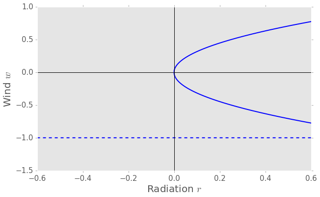

```python
plt.figure(figsize = (10, 6))

# Radiation r at which the solution is to be computed.
r = np.linspace(-0.6, 0.6, 5000)

# plot positive and negative square roots
plt.plot(r, np.sqrt(r), 'b-', lw = 2)
plt.plot(r, -np.sqrt(r), 'b-', lw = 2)
plt.plot(r, 0*r - 1, "b-", lw = 2, ls='--')  # constant solution

# axes limits
plt.xlim([-0.6, 0.6])
plt.ylim([-1.5, 1])

# labels
plt.xlabel('Radiation $r$', fontsize = 20); plt.ylabel('Wind $w$', fontsize = 20)
plt.xticks(fontsize = 15); plt.yticks(fontsize = 15)
plt.axhline(y=0, color='k')
plt.axvline(x=0, color='k')
plt.grid()
plt.show()
```

Notice that solutions for $w$ when $l = 0$ DNE for $r < 0$.

##### Let's look at the case when $l = 1$:

$l = 1$ gives us $ w^3 + w^2 - (1 + r) w - r = 0 $

This equation is impossible to factor and solve algebraically, so let's use a numerical solution:

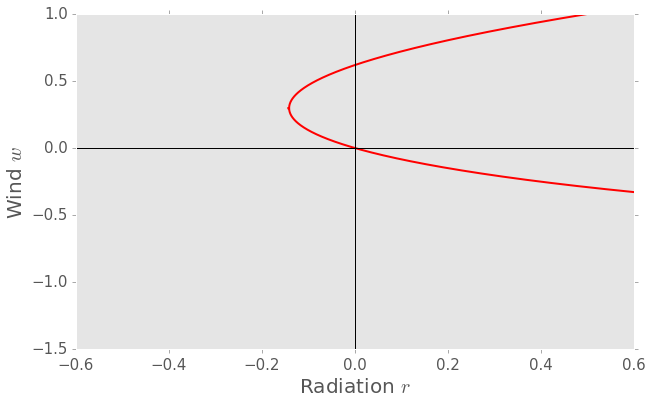

```python
plt.figure(figsize = (10, 6))

neg = []
pos = []
r = np.linspace(-0.142, 0.6, 5000)
for num in r:
    func = lambda w: w**3 + w**2 - w - num*w - num  # Define the expression whose roots we want to find

    # Use the numerical solver to find the roots
    neg.append(fsolve(func, -0.5))  # negative roots
    pos.append(fsolve(func, 0.5))  # positive roots

# plot positive and negative square roots
plt.plot(r, neg, 'r-', lw = 2)
plt.plot(r, pos, 'r-', lw = 2)

# axes limits
plt.xlim([-0.6, 0.6])
plt.ylim([-1.5, 1])

# labels
plt.xlabel('Radiation $r$', fontsize = 20); plt.ylabel('Wind $w$', fontsize = 20)
plt.xticks(fontsize = 15); plt.yticks(fontsize = 15)
plt.axhline(y = 0, color = 'k')
plt.axvline(x = 0, color = 'k')
plt.grid()
plt.show()
```

We see that solutions when $l = 1$ DNE for $r <\approx-0.15$

#### Quick Analysis

Both solutions look like the square root of $r$ with some phase changes. Then, generally, we can assume that the minima point (if we switch axes) for the solution of $w$ for some $l$ is the threshold (critical point) solution.

Note that as we increased $l$, $w$ increased and $r$ decreased at the critical point.

#### Solving for the critical point

We can solve for this equilibrium threshold ($w_c, r_c$) by finding these minimum points with respect to $l$.

Solve for $r$ in the nondimensional governing equation:

$ r_c= \frac{w_c^3 + w_c^2 - l w_c}{(w_c + 1)} $

Now take the derivative using quotient rule:

$ \frac{dr_c}{dw_c} = \frac{2w(w_c + 1)^2 - 1}{(w_c + 1)^2} $

Set $ \frac{dr_c}{dw_c} = 0 $:

$ 0 = 2w_c - \frac{l}{(w_c + 1)^2} $

Solve for $l$ and simplify:

$$ w_c(w_c + 1)^2 = \frac{l}{2} $$

Plotting gives us:

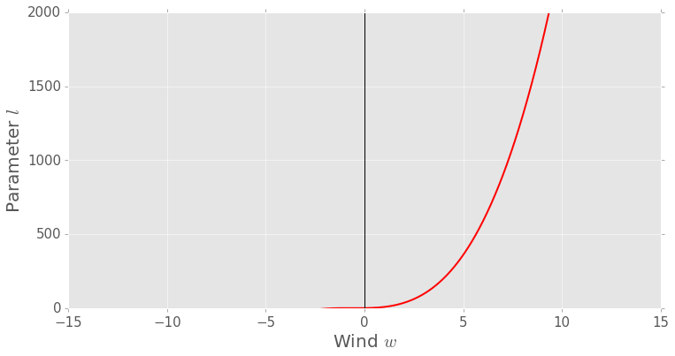

```python
plt.figure(figsize = (12, 6))

# Wind speeds at which the solution is to be computed.
w = np.linspace(-12, 12, 5000)

# plot
l = 2 * w * (w + 1) ** 2
plt.plot(w, l, 'r-', lw = 2)

# labels
plt.xlabel('Wind $w$', fontsize = 20); plt.ylabel('Parameter $l$', fontsize = 20)
plt.xticks(fontsize = 15); plt.yticks(fontsize = 15)
plt.ylim([0, 2000])
plt.axhline(y = 0, color = 'k')
plt.axvline(x = 0, color = 'k')
plt.show()
```

We can see generally that as $l$ increases, so does the nondimmensional wind $w$. This matches with our notes observation when increasing $l$ from 0 to 1. We ignore $l < 0$ because of physical impossiblity.

Now let's find $r_c$ by plugging $w_c$ back into the equation for r: $ r_c= \frac{w_c^3 + w_c^2 - l w_c}{(w_c + 1)} $

Plug in for $l$ in our equation for $r$:

$ r_c= \frac{w_c^3 + w_c^2 - 2 w_c^2(w_c + 1)^2}{(w_c + 1)} $

Factor:

$ r_c= \frac{w_c^2 (w_c + 1) - 2 w_c^2(w_c + 1)^2}{(w_c + 1)} $

Simplify:

$ r_c= w_c^2 - 2 w_c^2(w_c + 1) $

Factor and simplify:

$$ r_c= -w_c^2 (2 w_c + 1) $$

Graphing gives us:

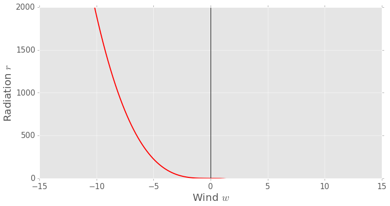

```python
plt.figure(figsize = (12, 6))

# Wind speeds at which the solution is to be computed.
w = np.linspace(-12, 12, 5000)

# plot
r = (-w**2)*(2*w + 1)
plt.plot(w, r, 'r-', lw = 2)

# labels
plt.xlabel('Wind $w$', fontsize = 20); plt.ylabel('Radiation $r$', fontsize = 20)
plt.xticks(fontsize = 15); plt.yticks(fontsize = 15)
plt.ylim([0, 2000])
plt.axhline(y = 0, color = 'k')
plt.axvline(x = 0, color = 'k')
plt.show()
```

We can see here that as $w$ increases, which corresponds with $l$ increasing, $r$ decreases. This matches with our observations when increasing $l$ from 0 to 1.

#### Precipitation

Now let's take a look at the behavior of nondimensional precipitation $ \mathcal P = \frac{w}{w + 1} \\$ by first plotting when $l = 0$:

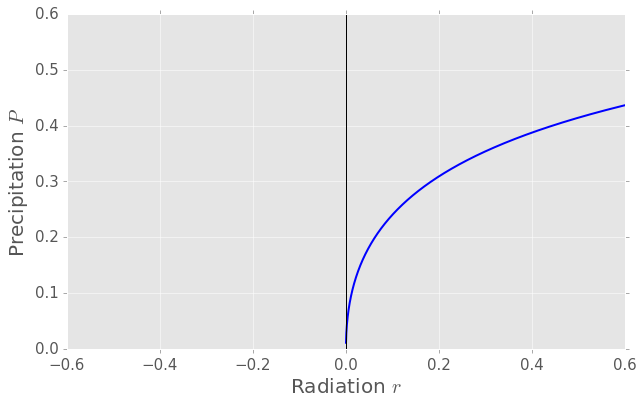

```python
plt.figure(figsize = (10, 6))

# range of r to compute
r = np.linspace(-0.6, 0.6, 5000)
# coorespoding values of p, using the solution w = sqrt(r)
p = (np.sqrt(r))/(np.sqrt(r) + 1)

# plot
plt.plot(r, p, 'b-', lw = 2)

# labels
plt.xlabel('Radiation $r$', fontsize = 20); plt.ylabel('Precipitation $P$', fontsize = 20)
plt.xticks(fontsize = 15); plt.yticks(fontsize = 15)
plt.ylim(0, 0.6)
plt.xlim(-0.6, 0.6)
plt.axhline(y = 0, color = 'k')
plt.axvline(x = 0, color = 'k')
plt.show()
```

Now let's plot the case when $l = 1$:

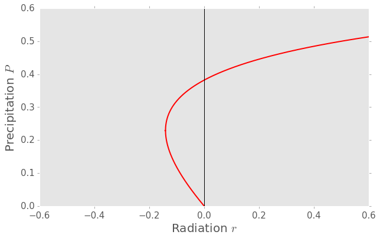

```python
plt.figure(figsize = (10, 6))

# negative roots
neg = []
pNeg = []
pos = []
pPos = []
# range of r to compute for
r = np.linspace(-0.142, 0.6, 5000)
for num in r:
    func = lambda w: w**3 + w**2 - w - num*w - num  # Define the expression whose roots we want to find

    # Use the numerical solver to find the roots
    sol = fsolve(func, -0.5)  # negative roots
    neg.append(sol)
    pNeg.append((sol)/(sol + 1))

    sol = fsolve(func, 0.5)  # positive roots
    pos.append(sol)
    pPos.append((sol)/(sol + 1))

# plot
plt.plot(r, pNeg, 'r-', lw = 2)
plt.plot(r, pPos, 'r-', lw = 2)

# axes limits
plt.ylim(0, 0.6)
plt.xlim(-0.6, 0.6)

# labels
plt.xlabel('Radiation $r$', fontsize = 20); plt.ylabel('Precipitation $P$', fontsize = 20)
plt.xticks(fontsize = 15); plt.yticks(fontsize = 15)
plt.axhline(y = 0, color = 'k')
plt.axvline(x = 0, color = 'k')
plt.grid()
plt.show()
```

#### Summary

Our equations for threshold critical points are:

$ w_c(w_c + 1)^2 = \frac{l}{2} $

$ r_c= -w_c^2 (2 w_c + 1) $

As the free variable $l$ increases, $r$ decreases, $w$ increases, and $\mathcal P$ increases.

## Results

### Combining everything

We know that the critic threshold occurs at ($w_c, r_c$) for each $l$, so let's plot the critical threshold line:

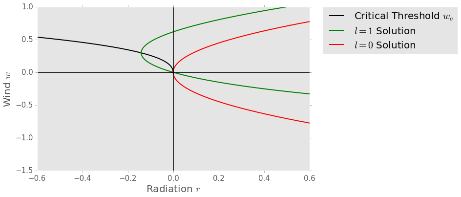

```python
plt.figure(figsize = (10, 6))

# find critical solutions w and r for a range of l (critical threshold)
solns = []  # w
r = []    # r
l = np.linspace(0, 3, 1000)  # l
for num in l:
    func = lambda w: w*(w + 1)**2 - num/2.0  # Define the expression whose roots we want to find

    # Use the numerical solver to find the roots
    sol = fsolve(func, 0.5)

    solns.append(sol)  # append the solution
    r.append((-(sol) ** 2) * (2 * sol + 1))  # apend the cooresponding r

# plot threshold curve
plt.plot(r, solns, 'k', lw = 2, label='Critical Threshold $w_c$')

# repeat solution for l = 1
neg = []
pos = []
r = np.linspace(-0.142, 0.6, 5000)
for num in r:
    func = lambda w: w**3 + w**2 - w - num*w - num

    # Use the numerical solver to find the roots
    neg.append(fsolve(func, -0.5))  # negative roots
    pos.append(fsolve(func, 0.5))  # positive roots

# plot l = 1 solution
plt.plot(r, neg, 'g-', lw = 2, label='$l = 1$ Solution')
plt.plot(r, pos, 'g-', lw = 2)

# plot l = 0 solution
plt.plot(r, np.sqrt(r), 'r-', lw = 2, label='$l = 0$ Solution')
plt.plot(r, -np.sqrt(r), 'r-', lw = 2)

# labels
plt.legend(bbox_to_anchor = (1.05, 1), loc = 2, borderaxespad = 0., fontsize = 20)
plt.xlabel('Radiation $r$', fontsize = 20); plt.ylabel('Wind $w$', fontsize = 20)
plt.xticks(fontsize = 15); plt.yticks(fontsize = 15)
plt.axhline(y = 0, color = 'k')
plt.axvline(x = 0, color = 'k')
plt.xlim([-0.6, 0.6])
plt.ylim([-1.5, 1])
plt.grid()
plt.show()
```

And we can do the same thing for dimensionless precipitation:

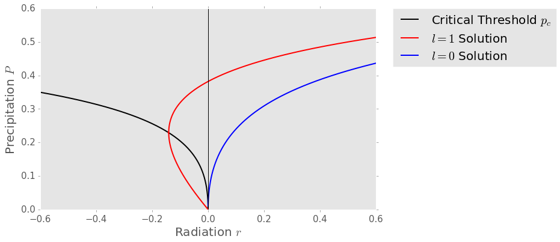

```python
plt.figure(figsize = (10, 6))

# find solutions w for a range of l
solns = []
r = []
l = np.linspace(0, 3, 1000)
for num in l:
    func = lambda w: w*(w + 1)**2 - num/2.0  # Define the expression whose roots we want to find

    # Use the numerical solver to find the roots
    sol = fsolve(func, 0.5)
    solns.append(sol)  # append the solution
    r.append((-(sol) ** 2) * (2 * sol + 1))  # apend the cooresponding r

# use the solutions w to find the solutions p
p = []
for num in solns:
    func = lambda p: num/(num + 1) - p # Define the expression whose roots we want to find

    # Use the numerical solver to find the roots
    p.append(fsolve(func, 0.5))  # append the solution

# plot threshold curve
plt.plot(r, p, 'k', lw = 2, label='Critical Threshold $p_c$')

# repeat l = 1 solution
pNeg = []
pPos = []
r = np.linspace(-0.142, 0.6, 5000)
for num in r:
    func = lambda w: w**3 + w**2 - w - num*w - num

    # Use the numerical solver to find the roots
    sol = fsolve(func, -0.5)  # negative roots
    pNeg.append((sol)/(sol + 1))

    sol = fsolve(func, 0.5)  # positive roots
    pPos.append((sol)/(sol + 1))

# plot l = 1 solution
plt.plot(r, pNeg, 'r-', lw = 2, label='$l = 1$ Solution')
plt.plot(r, pPos, 'r-', lw = 2)

# plot l = 0 solution
rr = np.linspace(-0.6, 0.6, 5000)
pp = (np.sqrt(rr))/(np.sqrt(rr) + 1)
plt.plot(rr, pp, 'b-', lw = 2, label='$l = 0$ Solution')

# labels
plt.xlabel('Radiation $r$', fontsize = 20); plt.ylabel('Precipitation $P$', fontsize = 20)
plt.xticks(fontsize = 15); plt.yticks(fontsize = 15)
plt.axhline(y = 0, color = 'k')
plt.axvline(x = 0, color = 'k')
plt.legend(bbox_to_anchor=(1.05, 1), loc=2, borderaxespad=0.,fontsize=20)
# axes limits
plt.ylim(0, 0.6)
plt.xlim(-0.6, 0.6)
plt.grid()
plt.show()
```

Let's look at the higher values of $l$ for the precipitation threshold:

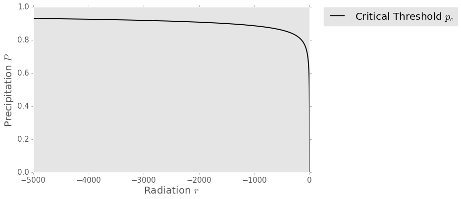

```python
plt.figure(figsize = (10, 6))

# find solutions w for a range of l
solns = []
r = []
l = np.linspace(0, 6000, 10000)
for num in l:
    func = lambda w: w*(w + 1)**2 - num/2.0  # Define the expression whose roots we want to find

    # Use the numerical solver to find the roots
    sol = fsolve(func, 0.5)
    solns.append(sol)  # append the solution
    r.append((-(sol) ** 2) * (2 * sol + 1))  # apend the cooresponding r

# use the solutions w to find the solutions p
p = []
for num in solns:
    func = lambda p: num/(num + 1) - p # Define the expression whose roots we want to find

    # Use the numerical solver to find the roots
    p.append(fsolve(func, 0.5))  # append the solution

# plot threshold curve
plt.plot(r, p, 'k', lw = 2, label='Critical Threshold $p_c$')

# labels
plt.xlabel('Radiation $r$', fontsize = 20); plt.ylabel('Precipitation $P$', fontsize = 20)
plt.xticks(fontsize = 15); plt.yticks(fontsize = 15)
plt.axhline(y = 0, color = 'k')
plt.axvline(x = 0, color = 'k')
plt.legend(bbox_to_anchor=(1.05, 1), loc=2, borderaxespad=0.,fontsize=20)
# axes limits
plt.ylim(0, 1)
plt.xlim(-5000, 0)
plt.grid()
plt.show()
```

## Conclusion

In conclusion, using tools in applied mathematics including dimensional, critical point analysis, and bifurcation we were able to successfully reproduce exactly the results found in the original paper. These methods can now be extended to include various other phyical processes, such as contribution by evaporation.

## Appendix

Levermann A, Schewe J, Petoukhov V, Held H (2009) Basic mechanism for abrupt monsoon transitions. Proc Nat Acad Sci USA 106:20572–20577. doi:10.1073/pnas.0901414106 http://www.pnas.org/content/106/49/20572